# 09_Lichen_specific_orthogroups

This script was used to do the following tasks:

1. Clean fasta headers and file names for fungal species (lichen and non-lichen fungi)
2. Run orthofinder to group the genes into orthogroups
3. Perform an enrichment analyses to find out genes enriched in lichen-forming fungi

#### Load libraries

```r
lapply(c("here","tidyverse","dplyr","phylotools","seqinr"), library, character.only = T)
```

```
## here() starts at /Users/gol22pin/Documents/Lichen_project_TSL/02_long_read_assemblies
```

[output not shown]

### 1. Clean fasta headers and file names for fungal species (lichen and non-lichen fungi)

```r
anot<-read_tsv("../analysis_and_temp_files/09_ortho/genomes_for_ortho.txt") #Metadata for 44 fungi - got this file from Gulnara
head(anot)
```

| ID | Species | Group | Ecology | Taxonomy | filename |
| --- | --- | --- | --- | --- | --- |
| Acastr1 | Acarospora strigata | Fungi | Lichen | Ascomycota; Lecanoromycetes; Acarosporales | Acastr1_GeneCatalog_proteins_20160720.fasta |
| Altal1 | Alternaria alternata | Fungi | Non_lichen | Ascomycota; Dothideomycetes; Pleosporales | Altal1_GeneCatalog_proteins_20141010.fasta |
| Amamu1 | Amanita muscaria | Fungi | Non_lichen | Basidiomycota | Amamu1_GeneCatalog_proteins_20120806.fasta |
| AOBU01 | Cyphellophora europaea | Fungi | Non_lichen | Ascomycota; Eurotiomycetes; Chaetothyriales | AOBU01.fasta |
| Artol1 | Arthrobotrys oligospora | Fungi | Non_lichen | Ascomycota; Orbiliomycetes; Orbiliales | Artol1_GeneCatalog_proteins_20131209.fasta |
| Ascim1 | Ascobolus immersus | Fungi | Non_lichen | Ascomycota; Pezizomycetes; Pezizales | Ascim1_GeneCatalog_proteins_20121221.fasta |

```r
#List and read fasta files from the directory input_files
file_names <- list.files("../analysis_and_temp_files/09_ortho/input_files", full.names=T)

#Read and merge into single data frame
fas_data <- map_dfr(file_names, ~ cbind(phylotools::read.fasta(.x), filename=basename(.x)))

#Replace special characters like * and numbers if any from the sequences
fas_data$seq.text <- gsub("[^a-zA-Z0-9 ]", "", fas_data$seq.text)

#Add new column for new fasta headers that are simplified or abbreviated
fasta_data<-left_join(fas_data,anot,by="filename")
length(unique(fasta_data$ID)) #number of unique IDs - should be 44 in this case
```

```
## [1] 44
```

```r
fasta_data <- fasta_data %>%
  group_by(filename) %>%
  mutate(new_headers=paste0(ID, "_", row_number())) #Creates a new_headers columns - in JGI mycocosm format

#Save this file for matching old and new fasta headers
write.table(fasta_data,"../analysis_and_temp_files/09_ortho/headers_dictionary.tsv",row.names=F,quote=F, sep="/t")

#Write each split data frame to a separate fasta file which will be saved in the output_files folder
fasta_data_split <- split(fasta_data, f=fasta_data$ID) # To write fasta file for each species (i.e. column "ID")
lapply(names(fasta_data_split), function(x) {
  write.fasta(as.list(fasta_data_split[[x]]$seq.text),
              fasta_data_split[[x]]$new_headers,
              paste0("../analysis_and_temp_files/09_ortho/output_files/", fasta_data_split[[x]]$ID[1], ".fasta"),
              open="w",
              as.string=F)
})
```

[output not shown]

[output cut: 76 more lines]

[output not shown]

### 2. Run orthofinder to group the genes into orthogroups

Check the files in the output directory, these will be used to run Orthofinder on the HPC

```r
#source package fc91613f-1095-4f67-b5aa-b86d702b36da
#ulimit -Sn 50000
#orthomatder -f lichen/
```

### 3. Perform an enrichment analysis to matd out genes enriched in lichen-forming fungi

From orthofinder results, parse the “Orthogroups.txt” file

```r
og<-read_tsv("../analysis_and_temp_files/09_ortho/Orthogroups.txt",show_col_types=F) #added colnames OGID and ProtID, and replaced ": " by "\t" beforehand
og1<-separate_rows(og, ProtID, sep=" ") #transform into two column table
head(og1)
```

| OGID | ProtID |
| --- | --- |
| OG0000000 | AOBU01_10214 |
| OG0000000 | AOBU01_11069 |
| OG0000000 | AOBU01_1179 |
| OG0000000 | AOBU01_2742 |
| OG0000000 | AOBU01_3312 |
| OG0000000 | AOBU01_6069 |

#### Use the dictionary file created previously to match ecology to the OGID and ProtIDs

```r
class<-fasta_data[c(9,7)]
colnames(class)[1]<-"ProtID"
og_class<-left_join(og1,class,by="ProtID")
head(og_class)
```

| OGID | ProtID | Ecology |
| --- | --- | --- |
| OG0000000 | AOBU01_10214 | Non_lichen |
| OG0000000 | AOBU01_11069 | Non_lichen |
| OG0000000 | AOBU01_1179 | Non_lichen |
| OG0000000 | AOBU01_2742 | Non_lichen |
| OG0000000 | AOBU01_3312 | Non_lichen |
| OG0000000 | AOBU01_6069 | Non_lichen |

#### Create the matrix to perform fisher exact test for enrichemt analysis

```r
enrch<-data.frame(table(og_class$OGID,og_class$Ecology))
mat<-pivot_wider(enrch,names_from=Var2,values_from=Freq)
colnames(mat)[1]<-"OGID"
mat$A<-mat$Lichen #sum of genes in a specific orthogroup in Lichen forming fungi
mat$B<-mat$Non_lichen #sum of a specific orthogroup in non-lichen forming fungi
mat$C<-sum(mat$A)-mat$A #sum of genes in remaining genes in lichen forming fungi
mat$D<-sum(mat$B)-mat$B #sum of genes in remaining genes in non-lichen forming fungi
```

#### Perform the fisher test

```r
AB<-mat[c(1,4:7)]
Fstat<-sapply(1:nrow(AB), function(i2) fisher.test(matrix(unlist(AB[i2,2:5]),nrow=2)))
mat$Pvalue<-unlist(t(Fstat)[,1])
mat$FDR <- p.adjust(mat$Pvalue, method= "BH") #Benjamin-hochberg FDR correction
PT<-as_tibble(mat$Pvalue)
FDR<-as_tibble(mat$FDR)
FDRL<-abs(log10(FDR[,1]))
FDRL <- data.frame(lapply(FDRL, function(x) {gsub("Inf", "200", x)}))
sig<-FDR
sig[sig[1]<0.0005,]<-4 #significant
sig[sig[1]<0.005,]<-3 #significant
sig[sig[1]<0.05,]<-2 #significant
sig[sig[1]<=1,]<-0 #not significant statistically
sigm<-sig
sigm[sigm[1]>1,]<-2 #significant
sigm[sigm[1]<1,]<-1
mat$sig<-sig$value
mat$sigm<-sigm$value
mat$Dir<-mat$A/mat$B > as.numeric(mat$C)/as.numeric(mat$D) #if TRUE, enriched in lichen, if false enriched in non_lichen forming fungi
mat$val<-mat$A/mat$B #more it is greater than 1, higher chances of being enriched in Lichen forming fungi
```

#### List the ProtIDs matching the respective OGIDs

```r
final<-left_join(mat,og_class,by="OGID")
head(final)
```

| OGID | Lichen | Non_lichen | A | B | C | D | Pvalue | FDR | sig | sigm | Dir | val | ProtID | Ecology |
| --- | --- | --- | --- | --- | --- | --- | --- | --- | --- | --- | --- | --- | --- | --- |
| OG0000000 | 415 | 777 | 415 | 777 | 164910 | 293438 | 0.414679 | 1 | 0 | 1 | FALSE | 0.5341055 | AOBU01_10214 | Non_lichen |
| OG0000000 | 415 | 777 | 415 | 777 | 164910 | 293438 | 0.414679 | 1 | 0 | 1 | FALSE | 0.5341055 | AOBU01_11069 | Non_lichen |
| OG0000000 | 415 | 777 | 415 | 777 | 164910 | 293438 | 0.414679 | 1 | 0 | 1 | FALSE | 0.5341055 | AOBU01_1179 | Non_lichen |
| OG0000000 | 415 | 777 | 415 | 777 | 164910 | 293438 | 0.414679 | 1 | 0 | 1 | FALSE | 0.5341055 | AOBU01_2742 | Non_lichen |
| OG0000000 | 415 | 777 | 415 | 777 | 164910 | 293438 | 0.414679 | 1 | 0 | 1 | FALSE | 0.5341055 | AOBU01_3312 | Non_lichen |
| OG0000000 | 415 | 777 | 415 | 777 | 164910 | 293438 | 0.414679 | 1 | 0 | 1 | FALSE | 0.5341055 | AOBU01_6069 | Non_lichen |

```r
write.table(final, file="../analysis_and_temp_files/09_ortho/lichen_enriched_ortho.tsv", quote=F, sep='\t', row.names=F)
#final<-read.delim("../analysis_and_temp_files/09_ortho/lichen_enriched_ortho.tsv")
```

The orthogroups **significantly enriched with lichen genes** (BH corrected p-value <=0.05) are the ones that are **“TRUE”** in the column **“Dir”** and have a value of **“2”** in the column **“sigm”**

Genes corresponding to these orthogroups are provided in the column **“ProtID”** and **“Ecology”**

#### List Xanpa genes from lichen-enriched orthogroups

- 1226 transcripts in total

```r
xp<-final %>% filter(Dir==T,sigm==2,grepl("Xanp",ProtID)) %>%
  left_join(fasta_data,by=c("ProtID"="new_headers")) %>%
  mutate(TranscriptID = str_replace(seq.name,"FUN","XANPAGTX0501")) %>%
  select(OGID,TranscriptID)
xp$TranscriptID<-gsub( " .*$", "", xp$TranscriptID)
write.table(xp, file="../analysis_and_temp_files/09_ortho/lichen_enriched_ortho_in_xanpa.tsv", quote=F, sep='\t', row.names=F)
```

#### Secreted proteins are overrepresented

- Used the consensus list of secreted proteins based on 3 tools: SignalP, WolfPSORT, and deepTMHMM

```r
funannot<-read.delim2("../../02_long_read_assemblies/analysis_and_temp_files/06_annotate_lecanoro/Annotation_with_OG.txt",sep="\t")
secreted<-read.delim2("../../10_lichen_effectors/analysis_and_temp_files/01_predicting_effectors/all_secreted_list.txt",header=F)
secreted$TranscriptID<-str_replace(secreted$V1,"FUN","XANPAGTX0501")

funannot2<-funannot %>% mutate(lichen_ortho=ifelse(TranscriptID %in% xp$TranscriptID,T,F),
                               secreted_consensus=ifelse(TranscriptID %in% secreted$TranscriptID,T,F))

write.table(funannot2, file="../analysis_and_temp_files/09_ortho/lichen_enriched_ortho_in_xanpa.tsv", quote=F, sep='\t', row.names=F)
```

- Lichen-specific orthogroups have disproportionately more secreted proteins:
  - 0.1174551 in lichen-specific orthogroups
  - Only 0.0543585 in the whole dataset

#### Look at CAZymes in the lichen-enriched genes / whole genome

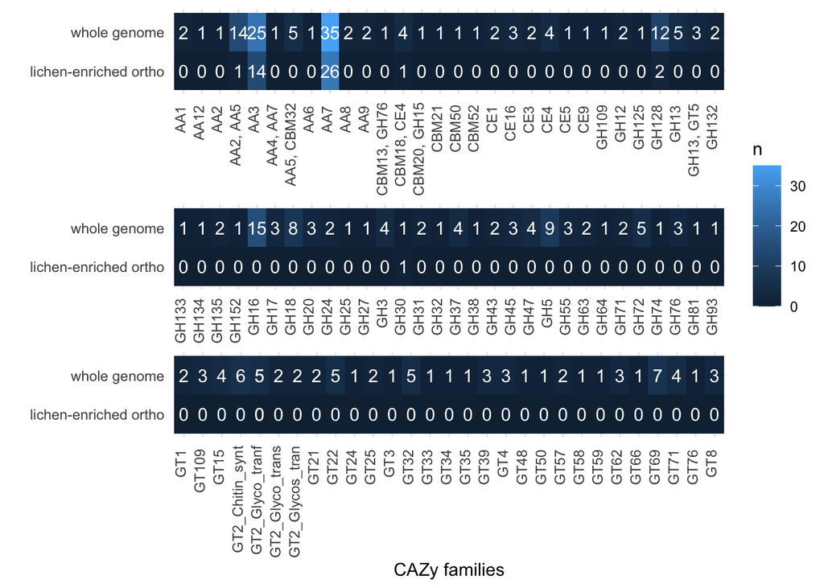

```r
cazy_whole<-funannot2 %>% group_by(CAZyme_new) %>% summarize(n=n()) %>% mutate(dataset="whole genome")
cazy_lich<-funannot2 %>% filter(lichen_ortho==T) %>%
  group_by(CAZyme_new) %>% summarize(n=n()) %>% mutate(dataset="lichen-enriched ortho")
cazy<-rbind(cazy_whole,cazy_lich) %>% pivot_wider(names_from = dataset,values_from = n,values_fill = 0) %>%
  pivot_longer(-CAZyme_new,names_to = "dataset",values_to = "n") %>% filter(!is.na(CAZyme_new))
cazy$technical<-1
cazy$technical[61:120]<-2
cazy$technical[121:180]<-3
cazy$CAZyme_new2<-cazy$CAZyme_new %>% substr(start = 1, stop = 15)

ggplot(cazy)+
  geom_tile(aes(x=CAZyme_new2,y=dataset,fill=n))+
  geom_text(aes(label=n,x=CAZyme_new2,y=dataset),color="white")+
  facet_wrap(~technical,nrow=3,scales="free")+xlab("CAZy families")+ylab("")+
  theme_minimal()+theme(strip.background = element_blank(),
  strip.text.x = element_blank(),axis.text.x = element_text(angle=90,hjust = 0.95,vjust=0.2))
```

- 56% of lichen-specific CAZymes are potentially secreted

```r
funannot2 %>% filter(lichen_ortho==T) %>% mutate(Secreted_if=ifelse(secreted_consensus==T,"Secreted","Not secreted")) %>% group_by(CAZyme_new,Secreted_if) %>% summarize(n=n()) %>% pivot_wider(names_from = Secreted_if,values_from = n,values_fill=0) %>% filter(!is.na(CAZyme_new))
```

| CAZyme_new | Secreted | Not secreted |
| --- | --- | --- |
| AA2, AA5 | 1 | 0 |
| AA3 | 7 | 7 |
| AA7 | 14 | 12 |
| CBM18, CE4 | 0 | 1 |
| GH128 | 2 | 0 |
| GH30 | 1 | 0 |

- But only 17% (25 out of 144) lichen-specific secreted enzymes are CAZymes

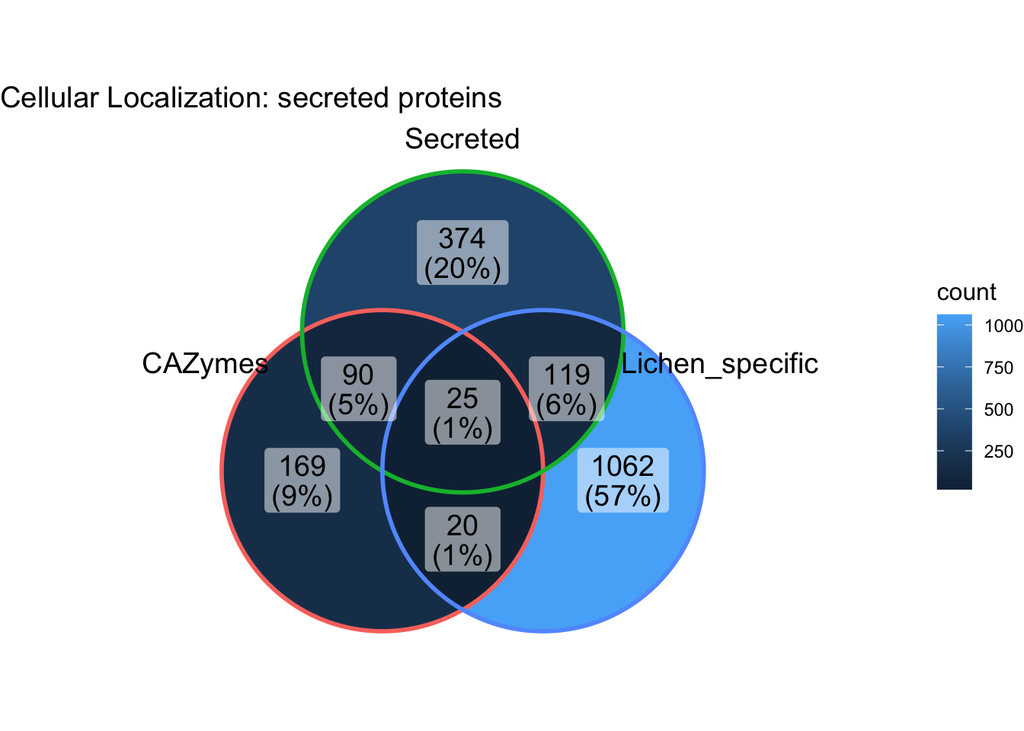

```r
library(ggVennDiagram)
venn1<-list(CAZymes = funannot2$TranscriptID[!is.na(funannot2$CAZyme_new)],
           Secreted = funannot2$TranscriptID[funannot2$secreted_consensus==T],
           Lichen_specific = funannot2$TranscriptID[funannot2$lichen_ortho==T])
l<-ggVennDiagram(venn1,label_size = 5,set_size=5)+labs(title = "Cellular Localization: secreted proteins")+theme(title=element_text(size=12))+scale_x_continuous(expand = expansion(mult = .4))
l
```

#### Look at proteases in the lichen-enriched genes / whole genome

- Only three families have lichen-enriched orthogroups
- A1A (from pepsin family): quite numerous in the genome, nearly half of them are lichen specific
- C19 are ubiquitinyl hydrolases. Also numerous in the genome, but only a few are lichen specific
- S53 are sedolisins, and are usually serceted prokaryotic enzsymes.

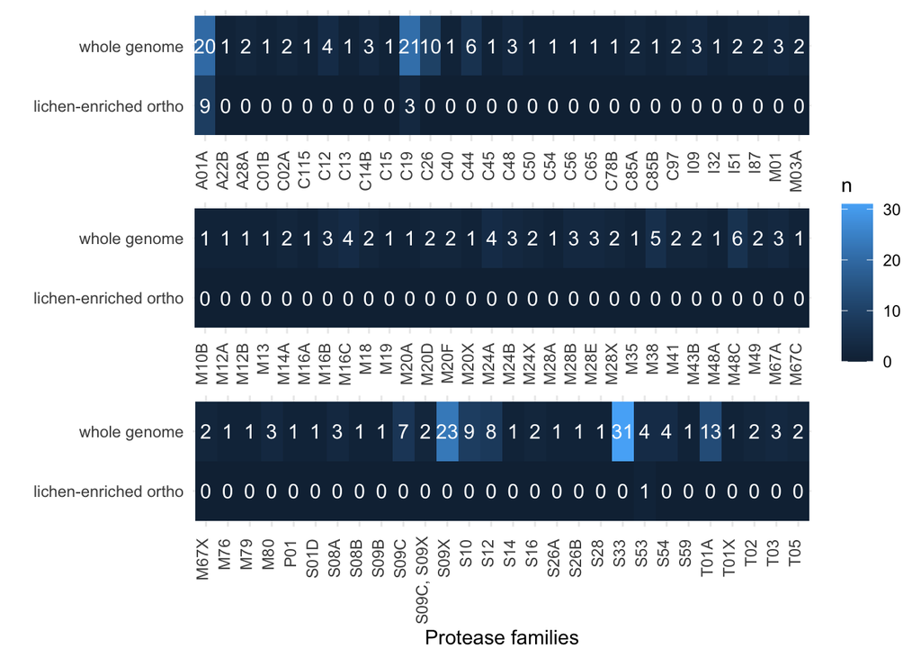

```r
protease_whole<-funannot2 %>% group_by(Protease_new) %>% summarize(n=n()) %>% mutate(dataset="whole genome")
protease_lich<-funannot2 %>% filter(lichen_ortho==T) %>%
  group_by(Protease_new) %>% summarize(n=n()) %>% mutate(dataset="lichen-enriched ortho")
protease<-rbind(protease_whole,protease_lich) %>% pivot_wider(names_from = dataset,values_from = n,values_fill = 0) %>%
  pivot_longer(-Protease_new,names_to = "dataset",values_to = "n") %>% filter(!is.na(Protease_new))
protease$technical<-1
protease$technical[61:120]<-2
protease$technical[121:176]<-3

ggplot(protease)+
  geom_tile(aes(x=Protease_new,y=dataset,fill=n))+
  geom_text(aes(label=n,x=Protease_new,y=dataset),color="white")+
  facet_wrap(~technical,nrow=3,scales="free")+xlab("Protease families")+ylab("")+
  theme_minimal()+theme(strip.background = element_blank(),
  strip.text.x = element_blank(),axis.text.x = element_text(angle=90,hjust = 0.95,vjust=0.2))
```

#### Enrichment analysis

- Prep data for interpro and GO trems

```r
ips_df <-funannot2 %>% select(TranscriptID,InterPro_new) %>%
  mutate(InterPro_new = strsplit(InterPro_new, ", I")) %>%
        unnest(InterPro_new) %>% mutate(InterPro_new=str_replace(InterPro_new,"^PR","IPR")) %>%
  mutate(short_term = substr(InterPro_new, 1,40))


ips_data <- list(
    term2protein = data.frame(
                        term = ips_df$InterPro_new,
                        gene = ips_df$TranscriptID
                        ),
    term2name = data.frame(
                        term = ips_df$InterPro_new,
                        name = ips_df$short_term
                        ),

    universe = unique(as.character(ips_df$TranscriptID))
)

go_df <-funannot2 %>% select(TranscriptID,GO.Terms_new) %>%
  mutate(GO.Terms_new = strsplit(GO.Terms_new, ",")) %>%
        unnest(GO.Terms_new) %>%
  mutate(GO.Terms=sub(".*? ", "", GO.Terms_new),
         short_term = substr(GO.Terms, 1,40))

go_data <- list(
    term2protein = data.frame(
                        term = go_df$GO.Terms_new,
                        gene = go_df$TranscriptID
                        ),
    term2name = data.frame(
                        term = go_df$GO.Terms_new,
                        name = go_df$short_term
                        ),

    universe = unique(as.character(go_df$TranscriptID))
)

### select genes from lichen specific orthgroups
geneList_lichspec = xp$TranscriptID
names(geneList_lichspec) = as.character(xp$TranscriptID)
geneList_lichspec = sort(geneList_lichspec, decreasing = TRUE)
geneList_lichspec <- names(geneList_lichspec)
```

- Intrepro enrichment shows a lot of secondary metabolism-related functions

```r
###enrichment analysis
enrich1<-clusterProfiler::enricher(geneList_lichspec,
    pAdjustMethod = "none",
    minGSSize = 1,
    maxGSSize = 2000,
    qvalueCutoff = 1,
    universe=ips_data$universe,
    TERM2GENE=ips_data$term2protein,
    TERM2NAME=ips_data$term2name)
```

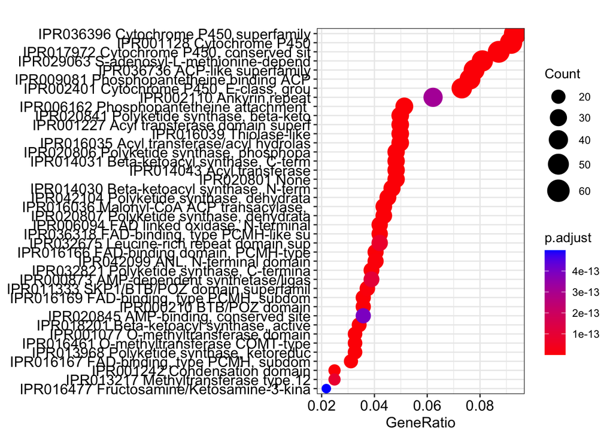

```r
enrichplot::dotplot(enrich1,showCategory=40,label_format=40)
```

- As a graph

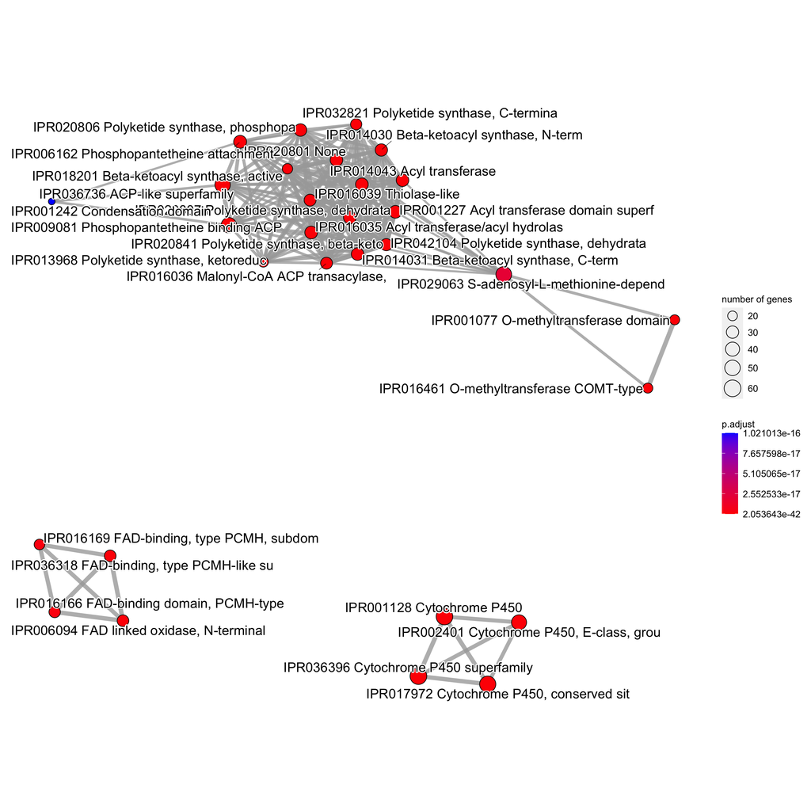

```r
enrich1_peirwise<-enrichplot::pairwise_termsim(enrich1)
enrichplot::emapplot(enrich1_peirwise)
```

- GO enrichment

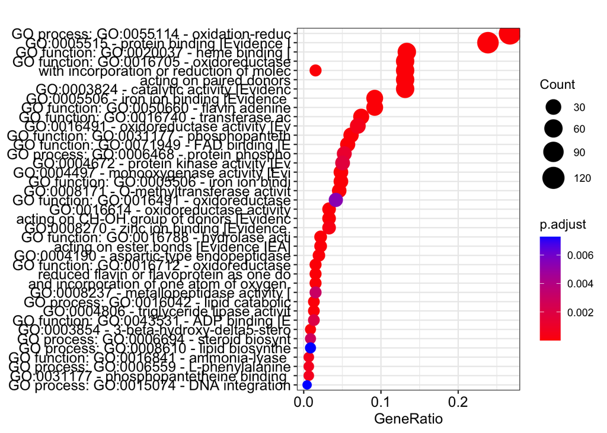

```r
###enrichment analysis
enrich2<-clusterProfiler::enricher(geneList_lichspec,
    pAdjustMethod = "none",
    minGSSize = 1,
    maxGSSize = 2000,
    qvalueCutoff = 1,
    universe=go_data$universe,
    TERM2GENE=go_data$term2protein,
    TERM2NAME=go_data$term2name)

enrichplot::dotplot(enrich2,showCategory=40,label_format=40)
```

#### 13% of lichen-specific genes have functions potentially relevant for fungal multicellularity

- Used a review by [Nagy et al.](https://www.biorxiv.org/content/10.1101/2021.12.09.471732v2.full.pdf) to compile a list of gene families/functions potentially involved in fungal multicellularity
  - Lists IDs in three databases: InterPRo, CAZy, and KEGG
  - Includes cell wall remodeling/biosynthesis, transcription factors, lipid metabolism genes, signalling pathways, etc
  - The whole table is in `../03_transcriptomic_analysis/analysis_and_temp_files/08_dge_culture_lichen/multicellularity.txt`
- Among the Xanpa annotation, 1552 genes belong to potentially multicellularity-involved families. Of these, 155 are from lichen-enriched orthgroups

```r
library(kableExtra)
mult_to_gene<-read.delim2("../../03_transcriptomic_analysis/analysis_and_temp_files/08_dge_culture_lichen/multicell_to_genes.txt")

mult_to_gene2<-funannot2 %>% filter(lichen_ortho==T) %>% inner_join(mult_to_gene) %>%
  select(TranscriptID,Product,Function,CAZyme_new,GO.Terms_new,InterPro_new,PFAM_new,Protease_new,KO,lichen_ortho)
mult_to_gene2 %>%
  kable(format = "html", col.names = colnames(mult_to_gene2)) %>%
  kable_styling() %>%
  kableExtra::scroll_box(width = "100%", height = "600px")
```

| TranscriptID | Product | Function | CAZyme_new | GO.Terms_new | InterPro_new | PFAM_new | Protease_new | KO | lichen_ortho |
| --- | --- | --- | --- | --- | --- | --- | --- | --- | --- |
| XANPAGTX0501_000281-T1 | hypothetical protein | Transporters | NA | GO_function: GO:0022857 - transmembrane transporter activity [Evidence IEA], GO_process: GO:0055085 - transmembrane transport [Evidence IEA] | IPR011701 Major facilitator superfamily, IPR020846 Major facilitator superfamily domain, IPR036259 MFS transporter superfamily | PF07690 | NA |  | TRUE |
| XANPAGTX0501_000556-T1 | hypothetical protein | Protein ubiquitination | NA | GO_function: GO:0005515 - protein binding [Evidence IEA] | IPR000210 BTB/POZ domain, IPR011333 SKP1/BTB/POZ domain superfamily | PF00651 | NA |  | TRUE |
| XANPAGTX0501_000621-T1 | hypothetical protein | Transcription factors | NA | GO_function: GO:0003676 - nucleic acid binding [Evidence IEA] | IPR013087 Zinc finger C2H2-type | NA | NA |  | TRUE |
| XANPAGTX0501_000640-T1 | hypothetical protein | Cell surface and cell wall proteins | NA | GO_function: GO:0004190 - aspartic-type endopeptidase activity [Evidence IEA], GO_process: GO:0006508 - proteolysis [Evidence IEA] | IPR001461 Aspartic peptidase A1 family, IPR021109 Aspartic peptidase domain superfamily, IPR033121 Peptidase family A1 domain, IPR034164 Pepsin-like domain | PF00026 | A01A |  | TRUE |
| XANPAGTX0501_000656-T1 | hypothetical protein | Cell surface and cell wall proteins | NA | NA | IPR000772 Ricin B, lectin domain, IPR035992 Ricin B-like lectins | NA | NA |  | TRUE |
| XANPAGTX0501_000658-T1 | hypothetical protein | Protein ubiquitination | NA | GO_function: GO:0005515 - protein binding [Evidence IEA] | IPR001810 F-box domain, IPR032675 Leucine-rich repeat domain superfamily, IPR036047 F-box-like domain superfamily | PF12937 | NA |  | TRUE |
| XANPAGTX0501_000660-T1 | hypothetical protein | Protein ubiquitination | NA | GO_function: GO:0005515 - protein binding [Evidence IEA] | IPR001810 F-box domain, IPR032675 Leucine-rich repeat domain superfamily, IPR036047 F-box-like domain superfamily | PF12937 | NA |  | TRUE |
| XANPAGTX0501_000684-T1 | hypothetical protein | Transporters | NA | NA | IPR036259 MFS transporter superfamily | NA | NA |  | TRUE |
| XANPAGTX0501_000731-T1 | hypothetical protein | Cell surface and cell wall proteins | NA | GO_function: GO:0004190 - aspartic-type endopeptidase activity [Evidence IEA], GO_process: GO:0006508 - proteolysis [Evidence IEA] | IPR001461 Aspartic peptidase A1 family, IPR001969 Aspartic peptidase, active site, IPR021109 Aspartic peptidase domain superfamily, IPR033121 Peptidase family A1 domain | PF00026 | A01A |  | TRUE |
| XANPAGTX0501_000731-T2 | hypothetical protein | Cell surface and cell wall proteins | NA | GO_function: GO:0004190 - aspartic-type endopeptidase activity [Evidence IEA], GO_process: GO:0006508 - proteolysis [Evidence IEA] | IPR001461 Aspartic peptidase A1 family, IPR001969 Aspartic peptidase, active site, IPR021109 Aspartic peptidase domain superfamily, IPR033121 Peptidase family A1 domain | PF00026 | A01A |  | TRUE |
| XANPAGTX0501_000837-T1 | hypothetical protein | RNA binding proteins | NA | GO_function: GO:0003676 - nucleic acid binding [Evidence IEA] | IPR000504 RNA recognition motif domain, IPR012677 Nucleotide-binding alpha-beta plait domain superfamily, IPR035979 RNA-binding domain superfamily | NA | NA |  | TRUE |
| XANPAGTX0501_000926-T1 | hypothetical protein | Acetyl-CoA production and metabolism | NA | GO_function: GO:0003824 - catalytic activity [Evidence IEA], GO_function: GO:0016491 - oxidoreductase activity [Evidence IEA], GO_function: GO:0016740 - transferase activity [Evidence IEA], GO_functio… | IPR001227 Acyl transferase domain superfamily, IPR006162 Phosphopantetheine attachment site, IPR009081 Phosphopantetheine binding ACP domain, IPR011032 GroES-like superfamily, IPR013149 Alcohol dehydr… | PF00106, PF00107, PF00109, PF00550, PF00698, PF01209, PF02801, PF08241, PF08242, PF08659, PF13489, PF13602, PF13649, PF13847, PF14765 | NA |  | TRUE |
| XANPAGTX0501_000979-T1 | hypothetical protein | Protein ubiquitination | NA | GO_function: GO:0005515 - protein binding [Evidence IEA] | IPR000210 BTB/POZ domain, IPR011333 SKP1/BTB/POZ domain superfamily | PF00651 | NA |  | TRUE |
| XANPAGTX0501_001024-T1 | hypothetical protein | Protein ubiquitination | NA | GO_function: GO:0005515 - protein binding [Evidence IEA] | IPR001810 F-box domain, IPR032675 Leucine-rich repeat domain superfamily | NA | NA |  | TRUE |
| XANPAGTX0501_001027-T1 | hypothetical protein | Transporters | NA | NA | IPR036259 MFS transporter superfamily | NA | NA |  | TRUE |
| XANPAGTX0501_001153-T1 | hypothetical protein | Protein ubiquitination | NA | GO_function: GO:0005515 - protein binding [Evidence IEA] | IPR000210 BTB/POZ domain, IPR011333 SKP1/BTB/POZ domain superfamily | PF00651 | NA |  | TRUE |
| XANPAGTX0501_001160-T1 | hypothetical protein | Cell wall remodeling | NA | NA | IPR037176 Osmotin/thaumatin-like superfamily | NA | NA |  | TRUE |
| XANPAGTX0501_001582-T1 | hypothetical protein | Protein ubiquitination | NA | GO_function: GO:0005515 - protein binding [Evidence IEA] | IPR001810 F-box domain, IPR032675 Leucine-rich repeat domain superfamily, IPR036047 F-box-like domain superfamily | NA | NA |  | TRUE |
| XANPAGTX0501_001643-T1 | hypothetical protein | Protein ubiquitination | NA | GO_function: GO:0005515 - protein binding [Evidence IEA] | IPR001810 F-box domain, IPR032675 Leucine-rich repeat domain superfamily, IPR036047 F-box-like domain superfamily | PF12937 | NA |  | TRUE |
| XANPAGTX0501_001653-T1 | hypothetical protein | Transporters | NA | GO_component: GO:0016020 - membrane [Evidence IEA], GO_component: GO:0016021 - integral component of membrane [Evidence IEA], GO_function: GO:0022857 - transmembrane transporter activity [Evidence IEA… | IPR003663 Sugar/inositol transporter, IPR005828 Major facilitator, sugar transporter-like, IPR005829 Sugar transporter, conserved site, IPR020846 Major facilitator superfamily domain, IPR036259 MFS tr… | PF00083 | NA |  | TRUE |
| XANPAGTX0501_001657-T1 | hypothetical protein | Transporters | NA | GO_function: GO:0022857 - transmembrane transporter activity [Evidence IEA], GO_process: GO:0055085 - transmembrane transport [Evidence IEA] | IPR011701 Major facilitator superfamily, IPR020846 Major facilitator superfamily domain, IPR036259 MFS transporter superfamily | PF07690 | NA |  | TRUE |
| XANPAGTX0501_001669-T1 | hypothetical protein | Transporters | NA | NA | IPR036259 MFS transporter superfamily | NA | NA |  | TRUE |
| XANPAGTX0501_001687-T1 | hypothetical protein | Transporters | NA | GO_function: GO:0022857 - transmembrane transporter activity [Evidence IEA], GO_process: GO:0055085 - transmembrane transport [Evidence IEA] | IPR011701 Major facilitator superfamily, IPR020846 Major facilitator superfamily domain, IPR036259 MFS transporter superfamily | PF07690 | NA |  | TRUE |
| XANPAGTX0501_001816-T1 | hypothetical protein | Transcription factors | NA | GO_function: GO:0003676 - nucleic acid binding [Evidence IEA] | IPR013087 Zinc finger C2H2-type | NA | NA |  | TRUE |
| XANPAGTX0501_001830-T1 | hypothetical protein | Transcription factors | NA | GO_function: GO:0003676 - nucleic acid binding [Evidence IEA], GO_function: GO:0003700 - DNA-binding transcription factor activity [Evidence IEA], GO_function: GO:0043565 - sequence-specific DNA bindi… | IPR001766 Fork head domain, IPR013087 Zinc finger C2H2-type, IPR036388 Winged helix-like DNA-binding domain superfamily, IPR036390 Winged helix DNA-binding domain superfamily | PF00096, PF00250 | NA |  | TRUE |
| XANPAGTX0501_001856-T1 | hypothetical protein | Cell wall remodeling | NA | NA | IPR037176 Osmotin/thaumatin-like superfamily | NA | NA |  | TRUE |
| XANPAGTX0501_002067-T1 | hypothetical protein | Protein ubiquitination | NA | GO_function: GO:0005515 - protein binding [Evidence IEA] | IPR000210 BTB/POZ domain, IPR011333 SKP1/BTB/POZ domain superfamily | PF00651 | NA |  | TRUE |
| XANPAGTX0501_002137-T1 | hypothetical protein | Protein ubiquitination | NA | GO_function: GO:0005515 - protein binding [Evidence IEA] | IPR000210 BTB/POZ domain, IPR011333 SKP1/BTB/POZ domain superfamily | PF00651 | NA |  | TRUE |
| XANPAGTX0501_002395-T1 | hypothetical protein | Protein ubiquitination | NA | GO_function: GO:0005515 - protein binding [Evidence IEA] | IPR000210 BTB/POZ domain, IPR011333 SKP1/BTB/POZ domain superfamily | PF00651 | NA |  | TRUE |
| XANPAGTX0501_002415-T1 | hypothetical protein | Transporters | NA | NA | IPR036259 MFS transporter superfamily | NA | NA |  | TRUE |

[output cut: 125 more lines]

- Most of them are ubiquitination-related, transportes, TFs, and cell wall-related

```r
mult_to_gene2 %>% group_by(Function) %>% summarize(n=n()) %>% arrange(desc(n))
```

| Function | n |
| --- | --- |
| Protein ubiquitination | 49 |
| Transporters | 44 |
| Transcription factors | 23 |
| Cell surface and cell wall proteins | 16 |
| Acetyl-CoA production and metabolism | 7 |
| Lipid metabolism | 6 |
| Cell wall remodeling | 5 |
| Defense | 2 |
| Cell division, proliferation and growth | 1 |
| Chromatin regulation | 1 |

[output cut: 1 more lines]

#### Annanotated lichen-specific genes

- Of 1226 DGE lichen-specific genes, 555 have no functional annotation. This is 45%, compared to 0.3081806 across the whole genome

#### G-aplha and GPCRs

- Out of 15 proteins annotated as G-alpha or GPCR, none were from a lichen-enriched orthogroup

```r
funannot2 %>% select(TranscriptID,lichen_ortho,InterPro_new) %>%
  filter(grepl("IPR011025",InterPro_new)|grepl("IPR001770",InterPro_new)|grepl("IPR001632",InterPro_new)|
         grepl("IPR017981",InterPro_new)|grepl("IPR000832",InterPro_new)|grepl("IPR0010191",InterPro_new))
```

| TranscriptID | lichen_ortho | InterPro_new |
| --- | --- | --- |
| XANPAGTX0501_000513-T1 | FALSE | IPR001632 G-protein, beta subunit, IPR001680 WD40 repeat, IPR015943 WD40/YVTN repeat-like-containing domain superfamily, IPR017986 None, IPR019775 WD40 repeat, conserved site, IPR020472 G-protein beta… |
| XANPAGTX0501_001254-T1 | FALSE | IPR000832 GPCR, family 2, secretin-like, IPR017981 GPCR, family 2-like, transmembrane domain |
| XANPAGTX0501_001470-T1 | FALSE | IPR017981 GPCR, family 2-like, transmembrane domain, IPR023041 Glucose receptor Git3, N-terminal |
| XANPAGTX0501_001586-T1 | FALSE | IPR001019 Guanine nucleotide binding protein (G-protein), alpha subunit, IPR001781 Zinc finger, LIM-type, IPR002975 Fungal G-protein, alpha subunit, IPR011025 G protein alpha subunit, helical insertio… |
| XANPAGTX0501_001629-T1 | FALSE | IPR001019 Guanine nucleotide binding protein (G-protein), alpha subunit, IPR002975 Fungal G-protein, alpha subunit, IPR011025 G protein alpha subunit, helical insertion, IPR027417 P-loop containing nu… |
| XANPAGTX0501_001629-T2 | FALSE | IPR001019 Guanine nucleotide binding protein (G-protein), alpha subunit, IPR001781 Zinc finger, LIM-type, IPR002975 Fungal G-protein, alpha subunit, IPR011025 G protein alpha subunit, helical insertio… |
| XANPAGTX0501_002727-T1 | FALSE | IPR001019 Guanine nucleotide binding protein (G-protein), alpha subunit, IPR001781 Zinc finger, LIM-type, IPR002975 Fungal G-protein, alpha subunit, IPR011025 G protein alpha subunit, helical insertio… |
| XANPAGTX0501_004970-T1 | FALSE | IPR017981 GPCR, family 2-like, transmembrane domain, IPR023041 Glucose receptor Git3, N-terminal |
| XANPAGTX0501_005274-T1 | FALSE | IPR017981 GPCR, family 2-like, transmembrane domain, IPR023041 Glucose receptor Git3, N-terminal |
| XANPAGTX0501_005509-T1 | FALSE | IPR001632 G-protein, beta subunit, IPR001680 WD40 repeat, IPR015943 WD40/YVTN repeat-like-containing domain superfamily, IPR017986 None, IPR019775 WD40 repeat, conserved site, IPR020472 G-protein beta… |

[output cut: 5 more lines]